# Classification, pt. 1

Philip Waggoner, MACS 30100 University of Chicago

# Overview

Back to the 2016 ANES data for today.

```r
# load some libraries
library(tidyverse)
library(here)
library(patchwork)
library(tidymodels)
# load the 2016 ANES pilot study data
anes <- read_csv(here("data", "anes_pilot_2016.csv"))
# select some features and clean: party, and 2 fts
anes_short <- anes %>%
  select(pid3, fttrump, ftobama) %>%
  mutate(democrat = as.factor(ifelse(pid3 == 1, 1, 0)),
         fttrump = replace(fttrump, fttrump > 100, NA),
         ftobama = replace(ftobama, ftobama > 100, NA)) %>%
  drop_na()

anes_short <- anes_short %>%
  select(-c(pid3)) %>%
  relocate(c(democrat))

anes_short %>%
  skimr::skim()
```

Data summary

| Name | Piped data |
| --- | --- |
| Number of rows | 1195 |
| Number of columns | 3 |
| _______________________ |  |
| Column type frequency: |  |
| factor | 1 |
| numeric | 2 |
| ________________________ |  |
| Group variables | None |

**Variable type: factor**

| skim_variable | n_missing | complete_rate | ordered | n_unique | top_counts |
| --- | --- | --- | --- | --- | --- |
| democrat | 0 | 1 | FALSE | 2 | 0: 739, 1: 456 |

**Variable type: numeric**

| skim_variable | n_missing | complete_rate | mean | sd | p0 | p25 | p50 | p75 | p100 | hist |
| --- | --- | --- | --- | --- | --- | --- | --- | --- | --- | --- |
| fttrump | 0 | 1 | 38.32 | 36.52 | 0 | 2 | 30 | 72 | 100 | ▇▂▂▂▃ |
| ftobama | 0 | 1 | 48.55 | 38.04 | 0 | 5 | 52 | 87 | 100 | ▇▂▂▃▆ |

Fit to full data.

```r
# model fitting via tidymodels
# define mod and engine
mod <- logistic_reg() %>%
  set_engine("glm") %>%
  set_mode("classification")

# fit
logit <- mod %>%
  fit(democrat ~ .,
      data = anes_short)

# eval
logit %>%
  predict(anes_short) %>%
  bind_cols(anes_short) %>%
  metrics(truth = democrat,
          estimate = .pred_class)
```

| .metric | .estimator | .estimate |
| --- | --- | --- |
| accuracy | binary | 0.7983264 |
| kap | binary | 0.5795724 |

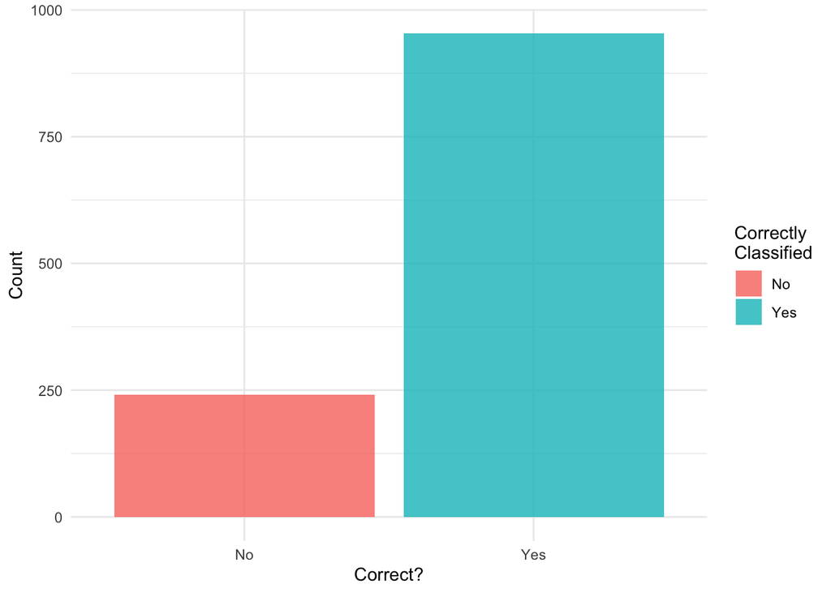

```r
# predict and viz
logit %>%
  predict(anes_short) %>%
  mutate(model = "logit",
         truth = anes_short$democrat) %>%
  mutate(correct = if_else(.pred_class == truth, "Yes", "No")) %>%
  ggplot() +
  geom_bar(alpha = 0.8, aes(correct, fill = correct)) +
  labs(x = "Correct?",
       y = "Count",
       fill = "Correctly\nClassified") +
  theme_minimal()
```

Explore.

```r
# explore some of the output
library(broom)

tidy(logit)
```

| term | estimate | std.error | statistic | p.value |
| --- | --- | --- | --- | --- |
| (Intercept) | -2.44723741 | 0.231873134 | -10.554209 | 4.857156e-26 |
| fttrump | -0.01141557 | 0.002642539 | -4.319925 | 1.560824e-05 |
| ftobama | 0.04097502 | 0.002797997 | 14.644416 | 1.462533e-48 |

Predicted probabilities.

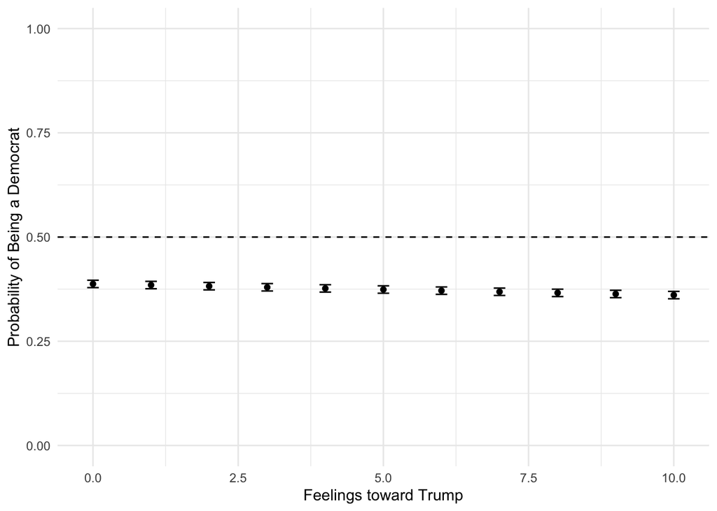

```r
dont_like_trump <- tibble(fttrump = 0:10,
                          ftobama = mean(anes_short$ftobama))

predicted_probs <- predict(logit,
                           dont_like_trump,
                           type = "prob")
# visualize results
dont_like_trump %>%
  bind_cols(predicted_probs) %>%
  ggplot(aes(x = fttrump,
             y = .pred_1)) +
  geom_point() +
  geom_errorbar(aes(ymin = (.pred_1) - sd(.pred_1),
                    ymax = (.pred_1) + sd(.pred_1)),
                width = 0.2) +
  geom_hline(yintercept = 0.50, linetype = "dashed") +
  ylim(0, 1) +
  labs(x = "Feelings toward Trump",
       y = "Probability of Being a Democrat") +
  theme_minimal()
```

Hmm… what happened?

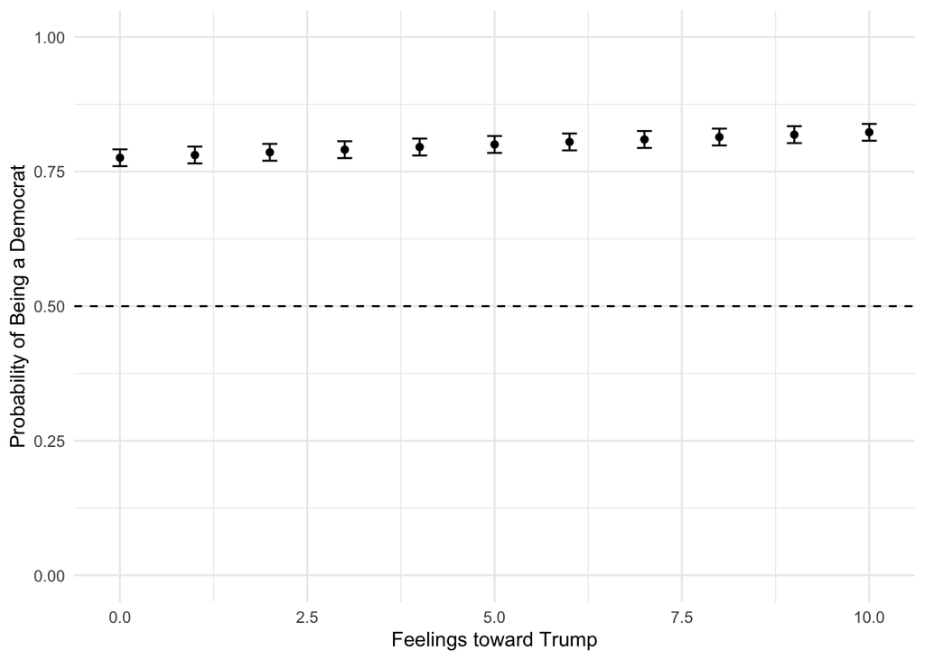

```r
dont_like_trump_love_obama <- tibble(fttrump = 0:10,
                                     ftobama = 90:100)

predicted_probs_new <- predict(logit,
                               dont_like_trump_love_obama,
                               type = "prob")
# visualize results
dont_like_trump_love_obama %>%
  bind_cols(predicted_probs_new) %>%
  ggplot(aes(x = fttrump,
             y = .pred_1)) +
  geom_point() +
  geom_errorbar(aes(ymin = (.pred_1) - sd(.pred_1),
                    ymax = (.pred_1) + sd(.pred_1)),
                width = 0.2) +
  geom_hline(yintercept = 0.50, linetype = "dashed") +
  ylim(0, 1) +
  labs(x = "Feelings toward Trump",
       y = "Probability of Being a Democrat") +
  theme_minimal()
```

Cross-validating a final, full model (from start to finish).

```r
## split
set.seed(1234)

split <- initial_split(anes_short,
                       prop = 0.70)
train <- training(split)
test <- testing(split)

cv_train <- vfold_cv(train,
                     v = 10)

## Now, create a recipe
recipe <- recipe(democrat ~ .,
                 data = anes_short)


# define mod and engine
mod <- logistic_reg() %>%
  set_engine("glm") %>%
  set_mode("classification")


# Define a workflow
workflow <- workflow() %>%
  add_recipe(recipe) %>%
  add_model(mod)

res <- workflow %>%
  fit_resamples(resamples = cv_train,
                metrics = metric_set(roc_auc, accuracy))
# finalize workflow and evaluate
final <- res %>%
  select_best(metric = "accuracy")

# Define a workflow; This is just a way to keep things neat and tidy (pun intended)
workflow <- workflow %>%
  finalize_workflow(final)

final_mod <- workflow %>%
  last_fit(split)


# inspect (if desired)
final_mod %>%
  collect_predictions()
```

| id | .pred_0 | .pred_1 | .row | .pred_class | democrat | .config |
| --- | --- | --- | --- | --- | --- | --- |
| train/test split | 0.2210365 | 0.77896353 | 4 | 1 | 1 | Preprocessor1_Model1 |
| train/test split | 0.2474599 | 0.75254006 | 10 | 1 | 1 | Preprocessor1_Model1 |
| train/test split | 0.5058734 | 0.49412661 | 13 | 0 | 1 | Preprocessor1_Model1 |
| train/test split | 0.9653485 | 0.03465154 | 15 | 0 | 0 | Preprocessor1_Model1 |
| train/test split | 0.2745527 | 0.72544726 | 36 | 1 | 1 | Preprocessor1_Model1 |
| train/test split | 0.9548121 | 0.04518794 | 39 | 0 | 0 | Preprocessor1_Model1 |
| train/test split | 0.9605932 | 0.03940677 | 40 | 0 | 0 | Preprocessor1_Model1 |
| train/test split | 0.5213779 | 0.47862214 | 41 | 0 | 1 | Preprocessor1_Model1 |
| train/test split | 0.9492461 | 0.05075388 | 43 | 0 | 0 | Preprocessor1_Model1 |
| train/test split | 0.1575383 | 0.84246169 | 49 | 1 | 1 | Preprocessor1_Model1 |

[output cut: 348 more lines]

```r
final_mod %>%
  collect_metrics()
```

| .metric | .estimator | .estimate | .config |
| --- | --- | --- | --- |
| accuracy | binary | 0.7877095 | Preprocessor1_Model1 |
| roc_auc | binary | 0.8784587 | Preprocessor1_Model1 |

```r
# create confusion matrix based on predictions from the model with conf_mat() from the yardstick package
final_mod %>%
  collect_predictions() %>%
  conf_mat(truth = democrat,
           estimate = .pred_class,
           dnn = c("Pred", "Truth"))
```

```
##     Truth
## Pred   0   1
##    0 173  26
##    1  50 109
```

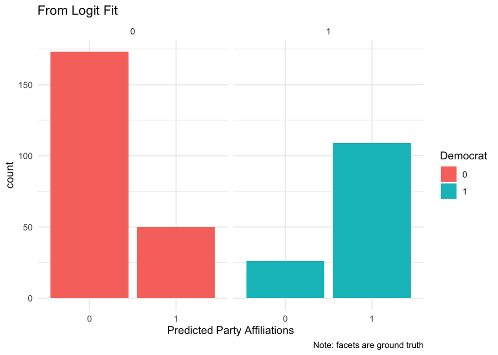

```r
# bar plot
final_mod %>%
  collect_predictions() %>%
  ggplot() +
  geom_bar(aes(x = .pred_class,
               fill = democrat)) +
  facet_wrap(~ democrat) +
  labs(title = "From Logit Fit",
       x = "Predicted Party Affiliations",
       fill = "Democrat",
       caption = "Note: facets are ground truth") +
  theme_minimal()
```

## Penalized Logistic Regression

What about a penalized logistic regression? Take a look at the replication materials (https://github.com/pdwaggoner/crim_algs) for a paper I co-authored with a student, predicting criminal recidivism for real criminal defendants. The paper is on the arXiv (https://arxiv.org/abs/2011.06422) if you’d like to read it. But the code combines this week’s material with last week’s material. It’s an opportunity to see some of this in action.

# On your own

For this section, you will work in small groups of 4-5. *I will create these groups at random*.

**IMPORTANT**: *Don’t forget that this code you’re working on here is due at the appropriate Canvas module (in the form of an attachment to a “Discussion” post) prior to 5:00 pm CDT tomorrow. You need only submit a **single** file/script to be considered for credit (i.e., this .Rmd with your code inserted below each question). Recall, I don’t care whether you got things right. I only care that attempts to each question have been made.*

Let’s end by taking a look at some other features’ effects on predicting party affiliation. Recall, we just said the classifier does a decent job at predicting party ID, but these are only two very specific features (feelings toward more recent, polarizing figures in American politics). So let’s expand the scope a bit.

1. Create a new subset of the full 2016 ANES data including the party id feature we have been working with (that is the dichotomous version we created), along with *all* feeling thermometers. Drop `NA`s after creating the subset.
2. Fit a new logistic regression classifier predicting party affiliation as a function of all feeling thermometers in your subset data. Present the coefficients from the output.
3. Recreate the bar plot from earlier depicting the accuracy of your solution.